# Online Web CES Data Exploration

Michellev Huang

2020-09-23

# Abstract

# Introduction

The data is from 2019 Canadian Election Study, specifically we used the 2019 CES Online Web Survey data to investigate anything interesting about the data. We explored the relationship between three variables that we are interested in which are age of survey participants, time duration of the survey and the main languages spoken by the participants.

This paper is mainly discussed three variables in the data set, however, there are more than 620 variables in total. Further work can be done to fit models with even more variables.

# Data

### Data description

The 2019 web data set of the Canadian Election Study includes 620 variables and around 38000 observations. The data I used is specifically from the web survey and the sampling units of the survey are people did the web survey in 2019. The target population is all Canadian citizen and permanent residents that aged 18 or older.

### Some initial explorations

The variables we focus on are:

- the ages of participants in the online survey
- the main language spoken by participants in the online survey
- the time taken by participants in the online survey

### Summary statistics for the two interested numerical variables age and duration:

- Summary statistics for age

```
##    Min. 1st Qu.  Median    Mean 3rd Qu.    Max.
##   18.00   35.00   49.00   48.72   62.00   99.00
```

- Summary statistics for duration

```
##    Min. 1st Qu.  Median    Mean 3rd Qu.    Max.
##     500     913    1189    1436    1604    9988
```

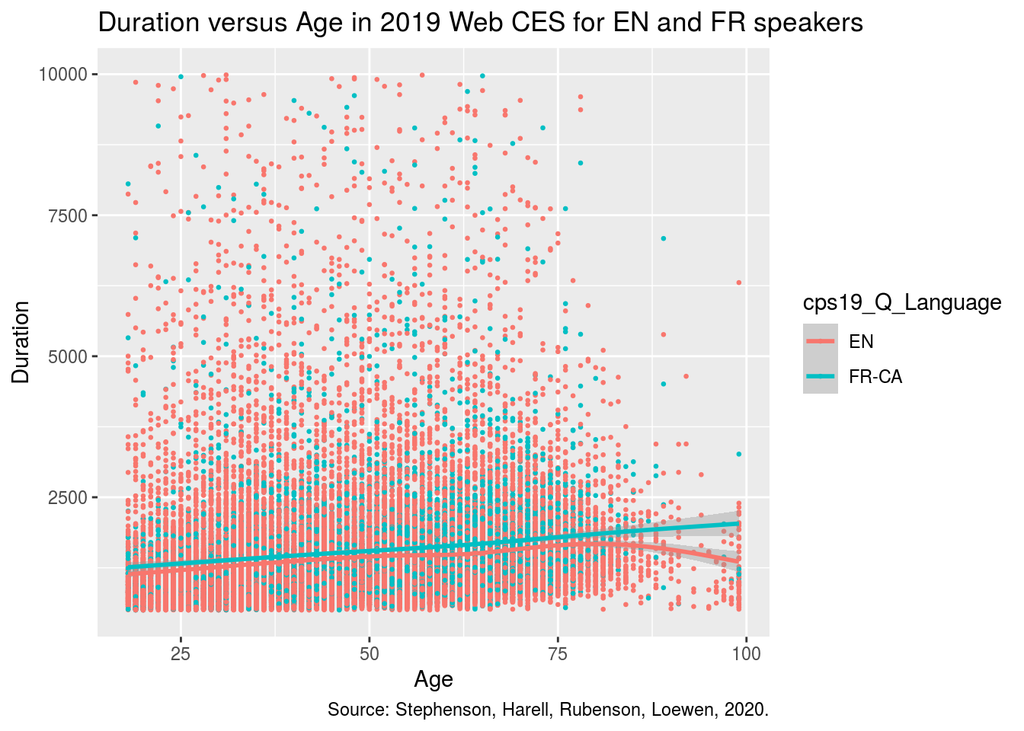

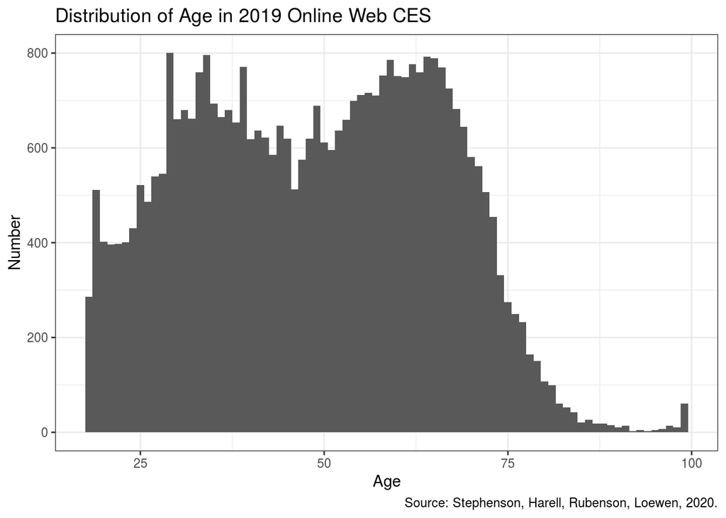

# Discussion

### Weaknesses and next steps

My weaknesses include that some of my findings are still required more check such as finding of potential confounding and lurking variables that we did not take into account. Further work can be done to fit models with even more variables.

# Blog Link

https://github.com/huangm50/cesR

# References

- Stephenson, Laura B; Harell, Allison; Rubenson, Daniel; Loewen, Peter John, 2020, ‘2019 Canadian Election Study - Online Survey’, https://doi.org/10.7910/DVN/DUS88V, Harvard Dataverse, V1
- Paul A. Hodgetts and Rohan Alexander (2020). cesR: Access the CES Datasets a Little Easier.. R package version 0.1.0.
- Hadley Wickham, Jim Hester and Winston Chang (2020). devtools: Tools to Make Developing R Packages Easier. https://devtools.r-lib.org/,https://github.com/r-lib/devtools.
- R Core Team (2020). R: A language and environment for statistical computing. R, Foundation for Statistical Computing, Vienna, Austria. URL, https://www.R-project.org/.
- JJ Allaire and Yihui Xie and Jonathan McPherson and Javier Luraschi and Kevin Ushey and Aron Atkins and Hadley Wickham and Joe Cheng and Winston Chang and Richard Iannone (2020). rmarkdown: Dynamic Documents for R. R package version 2.3. URL https://rmarkdown.rstudio.com.